# Accelerator Exercises Ch. 28

Otis

11/1/2017

### Load Packages

```r
library(tidyverse)
```

### Chapter 28

#### 28.2.1

*1*

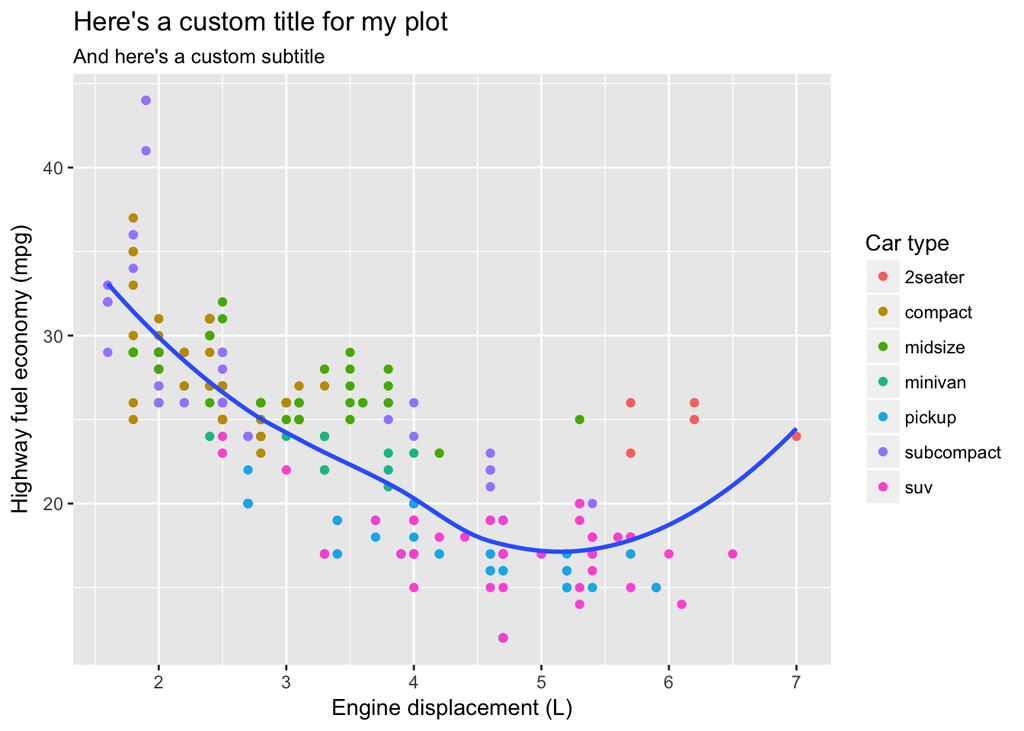

```r
ggplot(mpg, aes(displ, hwy)) +
  geom_point(aes(colour = class)) +
  geom_smooth(se = FALSE) +
  labs(
    x = "Engine displacement (L)",
    y = "Highway fuel economy (mpg)",
    title = "Here's a custom title for my plot",
    subtitle = "And here's a custom subtitle",
    colour = "Car type"
  )
```

*2*  
Break out geom smooth function by class to see how displ and hwy behave within the class of each car type. For car types with a small number of data points the geom_smooth function doesn’t have enough points for a strong fit, so we ignore the error message

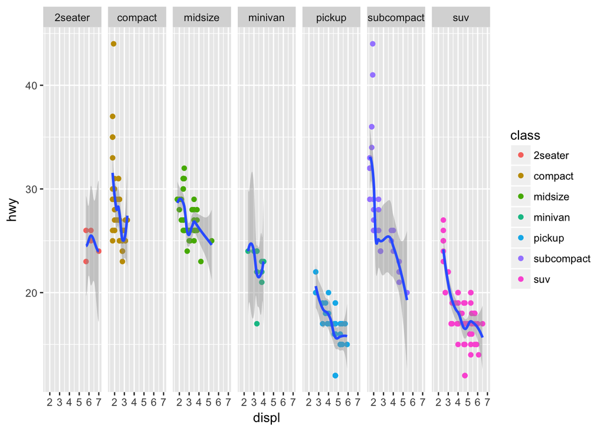

```r
ggplot(mpg,aes(displ, hwy)) +
  geom_point(aes(colour = class)) +
  facet_grid(.~class)+
  geom_smooth()
```

*3*

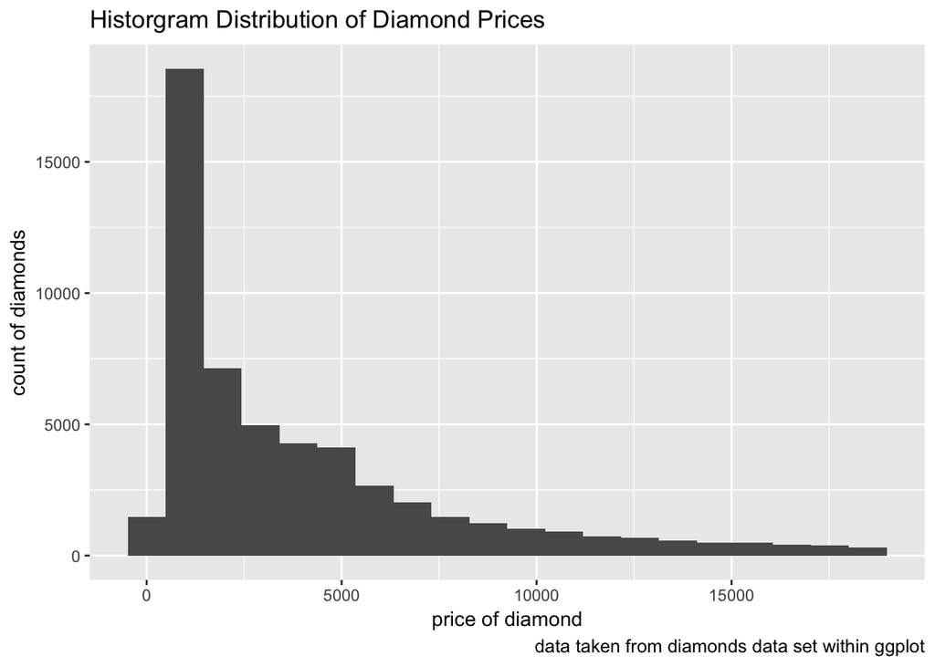

```r
diamonds %>%
  ggplot(aes(price))+
  geom_histogram(bins = 20) +
  labs(
    title = "Historgram Distribution of Diamond Prices",
    caption = "data taken from diamonds data set within ggplot",
    x = "price of diamond",
    y = "count of diamonds"
  ) +
  theme(legend.position = "none")
```

#### 28.3.1

*1*

First Solution I got: There’s a more elegant way to do this but it technically works

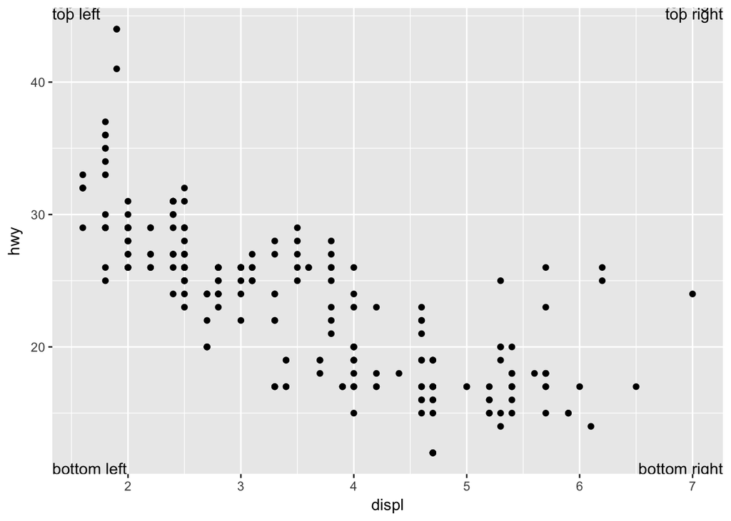

```r
displ <- c(Inf, Inf, -Inf, -Inf)
hwy <- c(Inf, -Inf, -Inf, Inf)
txt <- c("top right", "bottom right", "bottom left", "top left")
tmp <- tibble(displ, hwy, txt)
ggplot(mpg, aes(displ, hwy)) +
  geom_point() +

  geom_text(aes(label = txt), data = tmp, hjust ="top", vjust = "right") +
  geom_text(aes(label = txt), data = tmp, hjust ="bottom", vjust = "left") +
  geom_text(aes(label = txt), data = tmp, hjust ="bottom", vjust = "right") +
  geom_text(aes(label = txt), data = tmp, hjust ="top", vjust = "left")
```

Better solution (suggestion from Chris S. after meeting in Breakout Session)

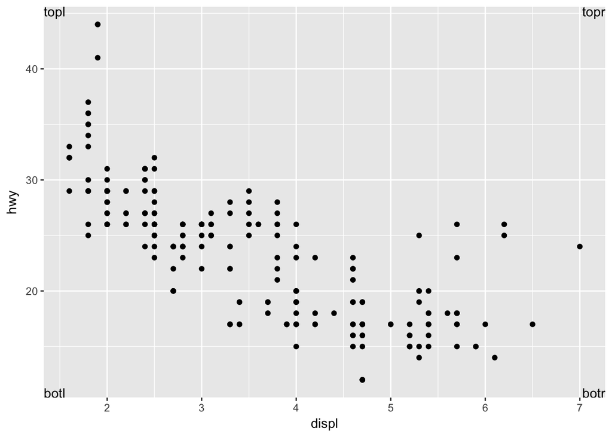

```r
label_tr <- tibble(displ = Inf, hwy = Inf)
label_br <- tibble(displ = Inf, hwy = -Inf)
label_tl <- tibble(displ = -Inf, hwy = Inf)
label_bl <- tibble(displ = -Inf, hwy = -Inf)

ggplot(mpg, aes(displ, hwy)) +
  geom_point() +
  geom_text(aes (label = "topr"), data = label_tr, vjust = "top", hjust = "right") +
    geom_text(aes (label = "botr"), data = label_br, vjust = "bottom", hjust = "right") +
  geom_text(aes (label = "topl"), data = label_tl, vjust = "top", hjust = "left") +
  geom_text(aes (label = "botl"), data = label_bl, vjust = "bottom", hjust = "left")
```

*2*

```r
?annotate
```

Can pass in small annotations (Such as text labels) as a vector instead of having to put them into a data frame

*3*

If text is generically defined across graph then it will pass through to each facet

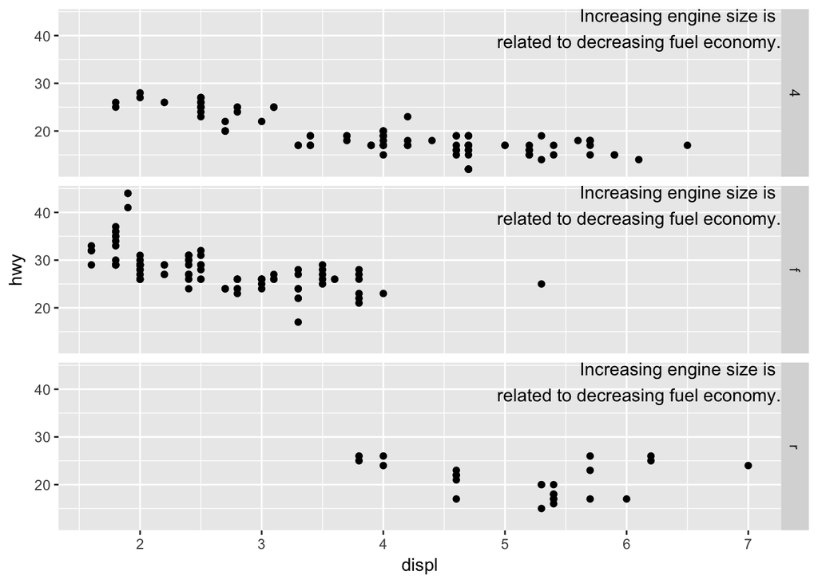

```r
label <- tibble(
  displ = Inf,
  hwy = Inf,
  label = "Increasing engine size is \nrelated to decreasing fuel economy."
)

ggplot(mpg, aes(displ, hwy)) +
  geom_point() +
  geom_text(aes(label = label), data = label, vjust = "top", hjust = "right") +
  facet_grid(drv~.)
```

But if text is restricted to a certain data point (as in the example below) that our data is being facted on, then it will only translate to the specific facet that has that value. ie: corvette is associated with drv r and thus only shows up in that specific facet

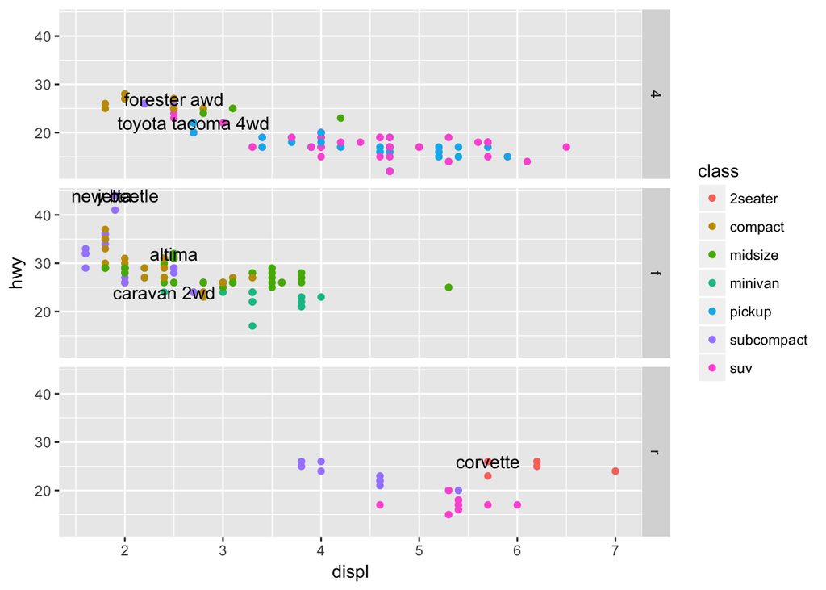

```r
best_in_class <- mpg %>%
  group_by(class) %>%
  filter(row_number(desc(hwy)) == 1)

ggplot(mpg, aes(displ, hwy)) +
  geom_point(aes(colour = class)) +
  geom_text(aes(label = model), data = best_in_class) +
  facet_grid(drv~.)
```

*4*  
“The `fill` aesthetic controls the background colour of the label” - R documentation

*5*  
arugments of arrow: angle, length, ends, type

Examples of different uses for arrows

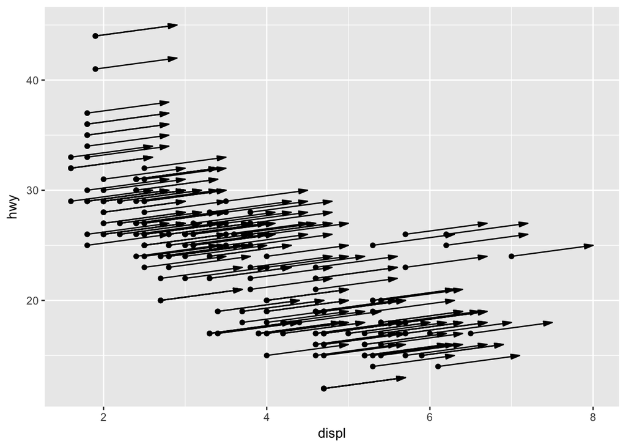

```r
ggplot(mpg, aes(displ, hwy)) +
  geom_point() +
  geom_segment(aes(x=displ, y=hwy, xend = displ +1, yend = hwy + 1), arrow = arrow(15, length = unit(0.1, "inches"), ends = "last", type = "closed"))
```

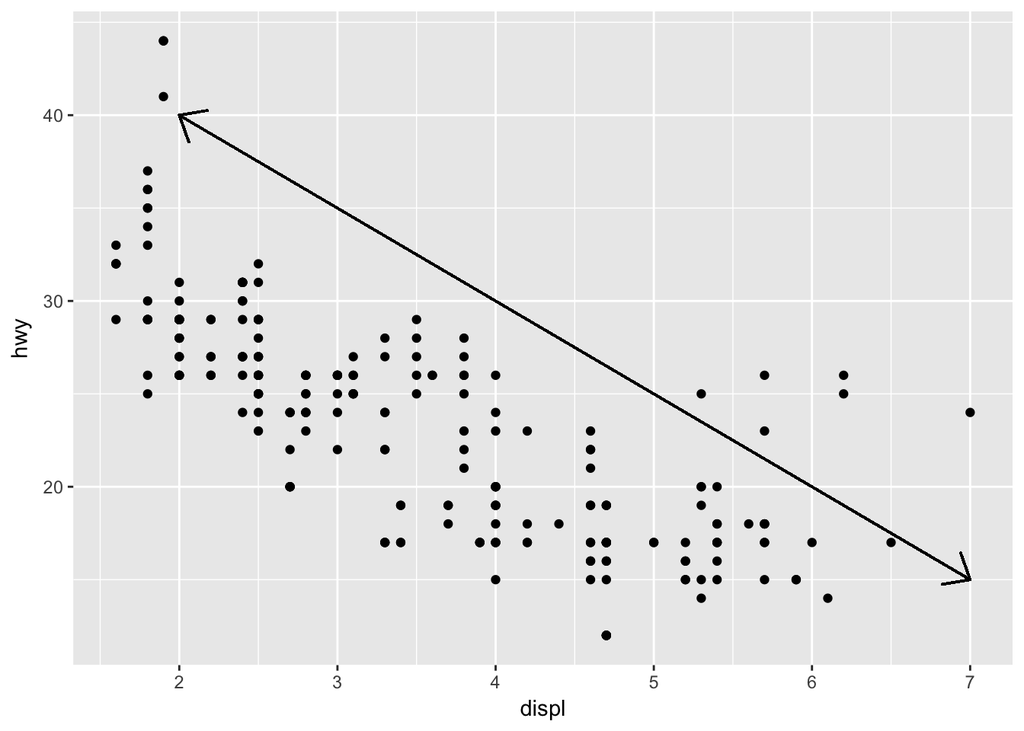

```r
ggplot(mpg, aes(displ, hwy)) +
  geom_point() +
  geom_segment(aes(x=2, y=40, xend = 7, yend = 15), arrow = arrow(40, length = unit(0.2, "inches"), ends = "both", type = "open"))
```

#### 28.4.4

*1*  
Load Hexbin Package

```r
library(hexbin)
```

Original code used scale_colour_gradient - need to use scale_fill_gradient to get red/white values to appear

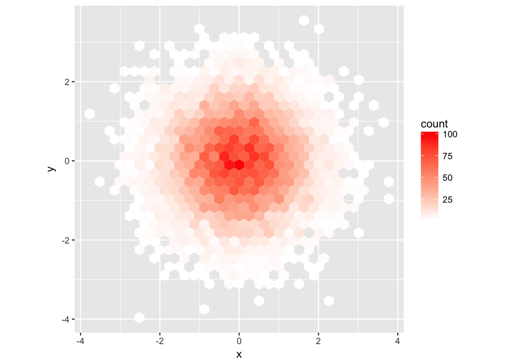

```r
df <- tibble(
  x = rnorm(10000),
  y = rnorm(10000)
)
ggplot(df, aes(x, y)) +
  geom_hex() +
  scale_fill_gradient(low = "white", high = "red") +
  coord_fixed()
```

*2*

First argument to both functions is `...`. For labs this is “A list of new name-value pairs”, for scale this is “Other arguments passed on to continuous_scale to control name, limits, breaks, labels and so forth.” They are both generic dots arguments, but control different things for each function

*3*

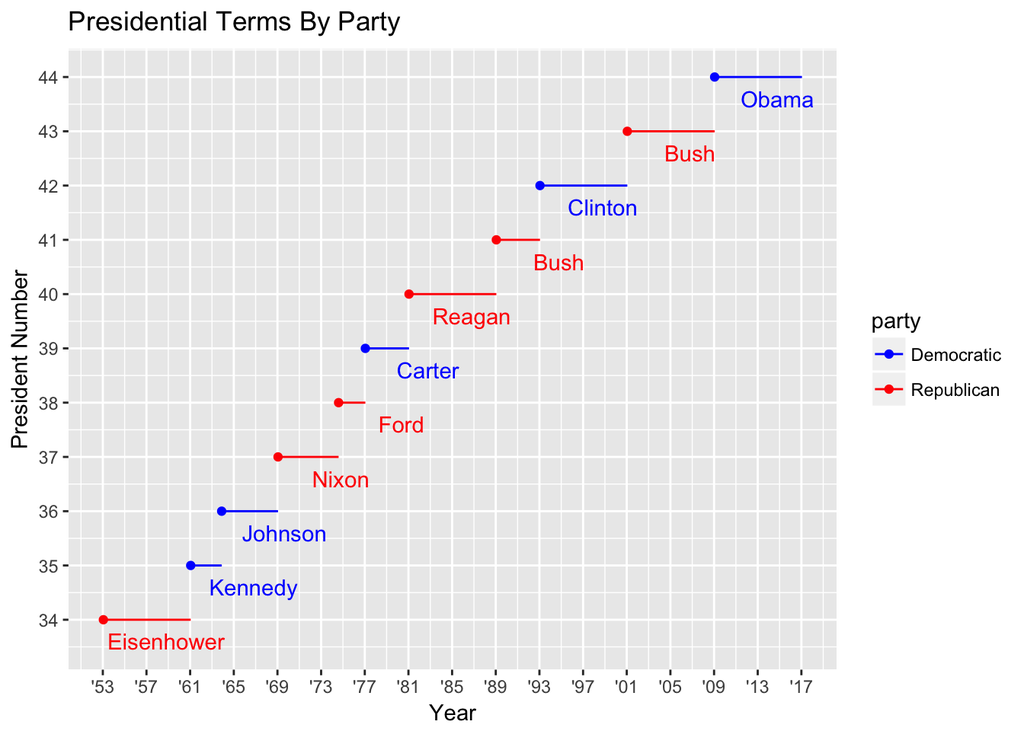

```r
presidential %>%
  mutate(id = 33 + row_number()) %>%
  ggplot(aes(start, id, colour = party)) +
    geom_point() +
    geom_segment(aes(xend = end, yend = id)) +
    scale_colour_manual(values = c(Republican = "red", Democratic = "blue")) +
  scale_y_continuous("President Number", breaks = seq(34,44), label = seq(34,44)) +
  scale_x_date("Year", date_breaks = "4 year", date_labels = "'%y") +
  ggtitle("Presidential Terms By Party") +
  geom_text(aes(label = presidential$name), nudge_y = -.4, nudge_x = 2100, show.legend =FALSE)
```

```r
?geom_text
```

*4*

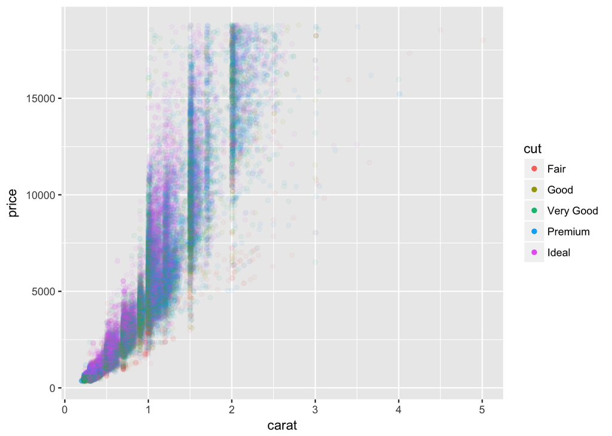

```r
ggplot(diamonds, aes(carat, price)) +
  geom_point(aes(colour = cut), alpha = 1/20) +
  guides(colour = guide_legend(override.aes = list(alpha=1)))
```